# JRF Experiential Survey

- Show All Code
- Hide All Code
- View Source

Author

Celestin Okoroji & Jolyon Miles-Wilson

## Intro

This document contains the results of several regression models focusing on Ethnicity and Sex in relation to various aspects of outsourced work. This document is intentionally terse and concentrates only on presenting results that have statistically significant findings.

All models use the same predictors: Age, Sex, Ethnicity, Arrival in the UK and Income Group. All models are weighted.

For each plot, if the point estimate and confidence interval is to the right of the vertical dotted line, the variable is associated with a higher outcome (holding all other variables constant). Vice versa, if the point estimate and confidence interval is to the left of the vertical line, the variable is associated with a lower outcome. If the confidence interval crosses the vertical line, the variable is not significantly associated with the outcome.

In most cases interaction effects between Sex and Ethnicity (and three-way interactions with Income group) were explored. If they are not reported here it indicates that these models were not better fits to the data than the main effects models.

## Improvements

The following regression model examines the relationship between the number of improvements suggested by outsourced workers i.e. the model sums the number of improvements suggested by each worker from a total of 15 possible options (such as higher pay, more flexible working hours etc).

The model shows that as Age increases the number of suggested improvements decreases. The same is true for Female compared to Male respondents. Notably, Black respondents were more likely to suggest a greater number of improvements compared with White respondents. This was not the case for any other Ethnic group. Low income had no significant effect on the number of improvements suggested.

**Code for Nerds**

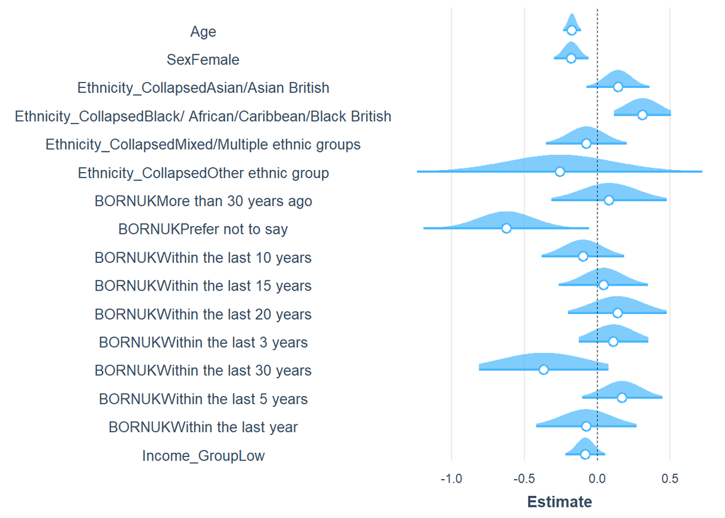

```r
plot_summs(What_Improvements_Score.fit1, plot.distributions = TRUE,
           rescale.distributions = TRUE, scale = TRUE, robust = TRUE, title = "What Improvements Score")
```

## Which Improvements Specifically

For brevity I am omitting all of the models in favour of brief overview of the significant results. Note that these models do not include the interaction effects. If particular improvements are not mentioned here, it is because there were no significant predictors (or significant results were uninteresting for another reason).

- **Pay**: Black respondents were more likely to suggest pay improvements compared to White respondents. There was no significant effect for other ethnic groups.
- **More Hours**: Age and Sex(female) associated with lower likelihood of suggesting more hours. People who arrived in the last year are much more likely to suggest more hours.
- **Less Hours**: Low pay associated with lower likelihood of suggesting less hours
- **More Consistency**: Age associated with lower likelihood of suggesting more consistency. Being Black associated with higher likelihood of suggesting more consistency. There was no significant effect for other ethnic groups.
- **More Flexibility**: Age associated with lower likelihood of suggesting more flexibility. Being Asian associated with higher likelihood of suggesting more flexibility. There was no significant effect for other ethnic groups.
- **Part of InHouse**: Sex (female) associated with lower likelihood of wanting to be part of InHouse
- **Enforce Rights**: Age associated with lower likelihood of suggesting enforcing rights
- **Management**: Age and Low pay associated with lower likelihood of suggesting management improvements
- **Autonomy**: Age and Sex associated with lower likelihood of suggesting autonomy improvements
- **Union**: Sex associated with lower likelihood of suggesting union improvements

# Rights Violations

Next we looked at Rights Violations. Again the number of rights violations reported is summed to create an overall score. Age and Sex have significant negative associations with the number of rights violations reported.

**Code for Nerds**

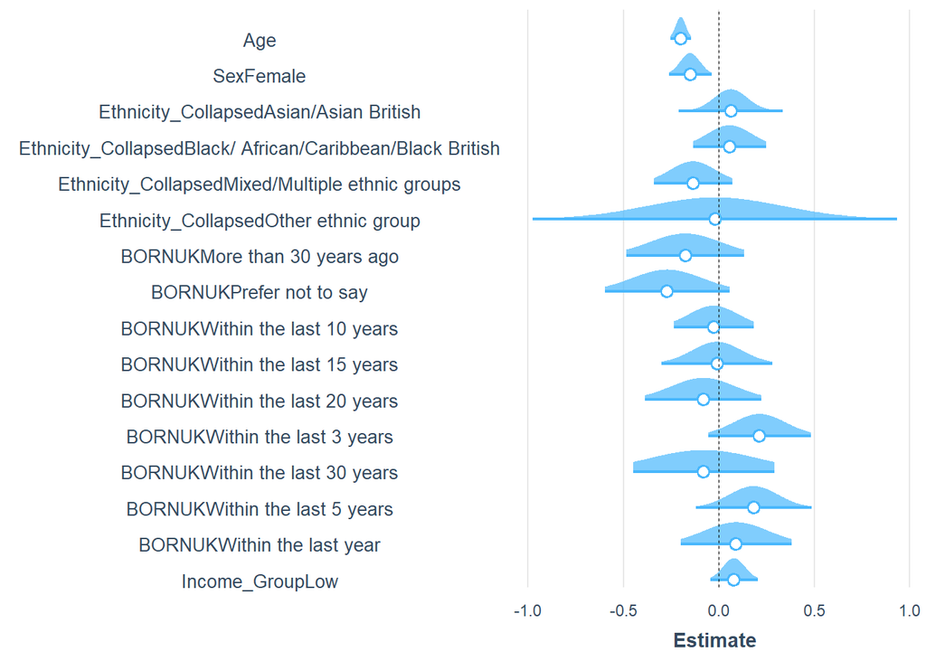

```r
plot_summs(Rights_Violations_Score.fit1, plot.distributions = TRUE,
           rescale.distributions = TRUE, scale = TRUE, robust = TRUE, title = "Rights Violations Score")
```

## Which Rights Violations Specifically

- **Paid On Time**: Age associated with lower likelihood of reporting not being Paid on Time.
- **Paid Correctly**: Age associated with lower likelihood of reporting not being Paid Correctly.
- **Leave Entitlement**: Age associated with lower likelihood of reporting not getting full leave entitlements.
- **Holiday Pay**: Age associated with lower likelihood of reporting not getting holiday pay. Selecting ‘Other’ Ethnic group was associated with higher likelihood of reporting not getting holiday pay.
- **Sick Pay**: Age and Sex associated with lower likelihood of reporting not getting sick pay.
- **Pay Slips**: Age and Sex associated with lower likelihood of reporting issues with Pay Slips. Low pay was associated with higher likelihood of reporting issues with Pay Slips.
- **Health and Safety**: Age and Sex associated with lower likelihood of reporting usses with Health and Safety.

# Clarity

The clarity variables created a reliable scale and thus we initially take the mean of these variables in one analysis. However, in discussion we recognise that the clarity related variables may represent distinct concepts related to general confidence in who to approach around certain matters and specific attitudes towards management and how they deal with specific scenarios related to discrimination. We have not yet explored these in detail.

**Code for Nerds**

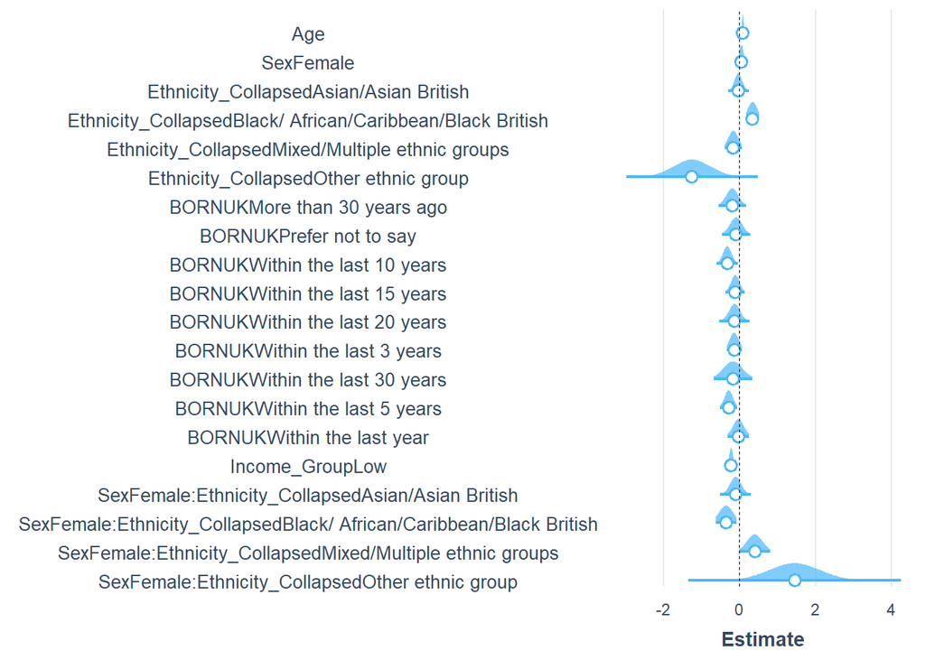

```r
plot_summs(Clarity.fit2, plot.distributions = TRUE,
           rescale.distributions = TRUE, scale = TRUE, robust = TRUE, title = "Clarity Overall Mean")
```

# Clarity Specifics

# Additional Exploration

At this point plots may be sufficient to elucidate the relationships between the variables in each case

### Age Discrimination

**Code for Nerds**

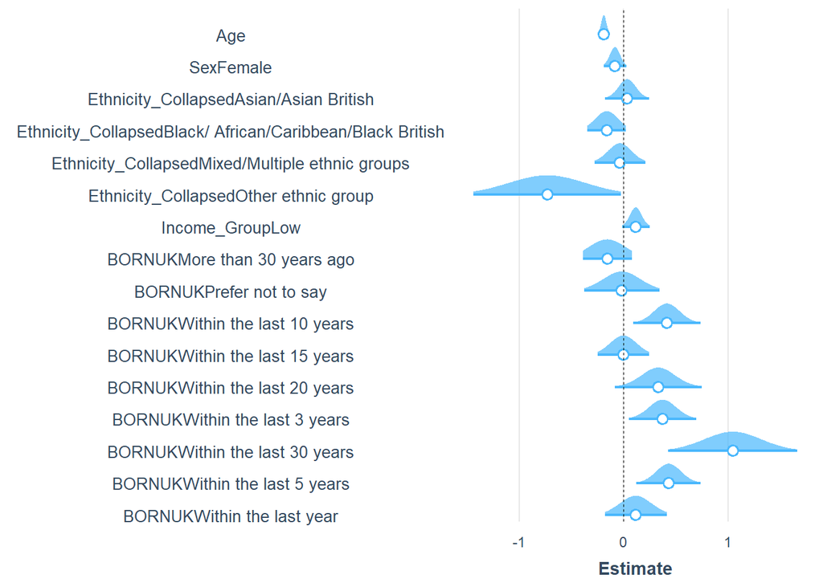

```r
plot_summs(client_discrimination_age.fit, plot.distributions = TRUE,
           rescale.distributions = TRUE, scale = TRUE, robust = TRUE, title = "Age Discrimination")
```

### Disability Discrimination

**Code for Nerds**

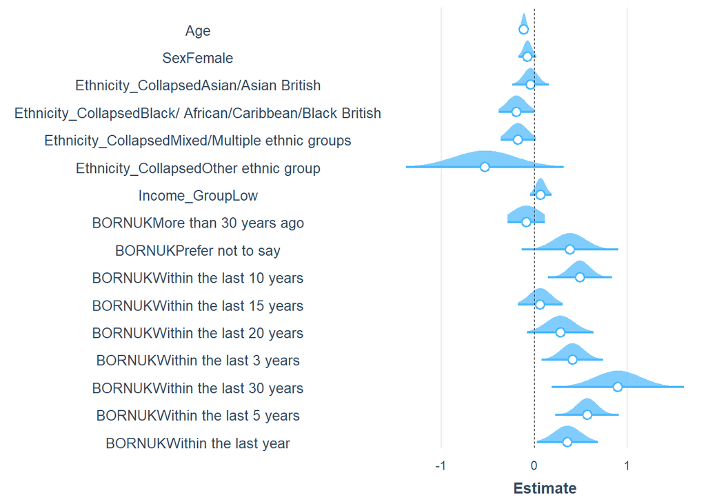

```r
plot_summs(Client_Discrimination_Disability.fit, plot.distributions = TRUE,
           rescale.distributions = TRUE, scale = TRUE, robust = TRUE, title = "Clarity Overall Mean")
```

### Nationality Discrimination

**Code for Nerds**

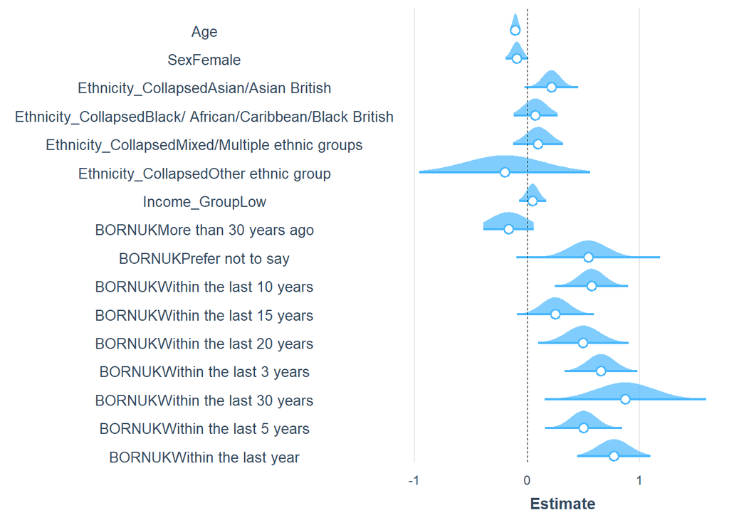

```r
plot_summs(Client_Discrimination_Nationality.fit, plot.distributions = TRUE,
           rescale.distributions = TRUE, scale = TRUE, robust = TRUE, title = "Nationality")
```

### Ethnic Disctimination

**Code for Nerds**

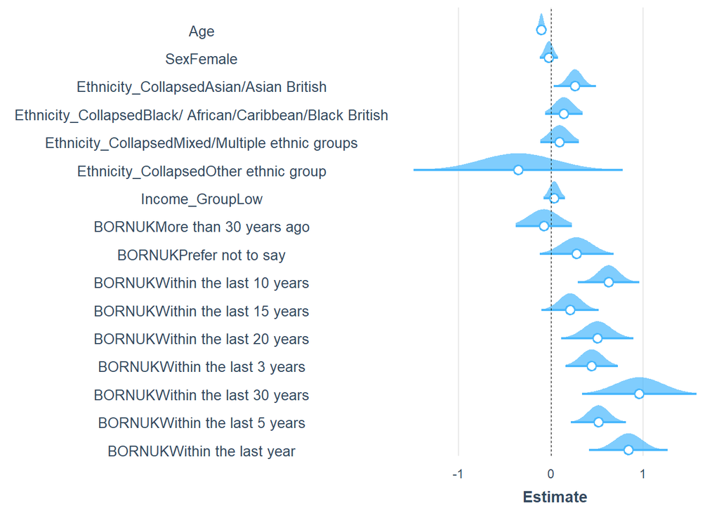

```r
plot_summs(Client_Discrimination_Ethnicity.fit, plot.distributions = TRUE,
           rescale.distributions = TRUE, scale = TRUE, robust = TRUE, title = "Ethnicity")
```

### Sex Discrimination

**Code for Nerds**

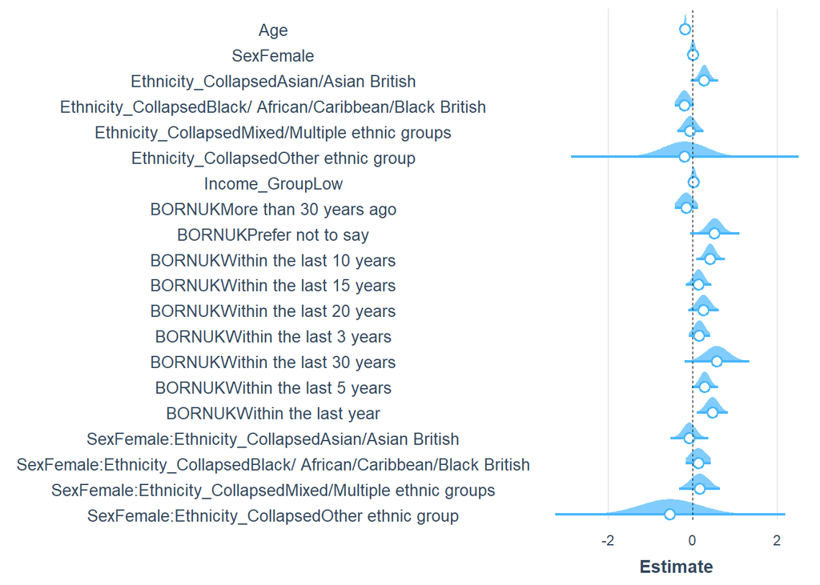

```r
plot_summs(Client_Discrimination_Sex.fit, plot.distributions = TRUE,
           rescale.distributions = TRUE, scale = TRUE, robust = TRUE, title = "Sex")
```

### TRADE UNION and TUCOV

**Code for Nerds**

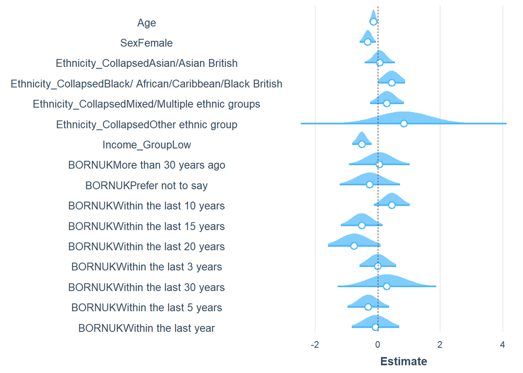

```r
plot_summs(trade_union.fit, plot.distributions = TRUE,
           rescale.distributions = TRUE, scale = TRUE, robust = TRUE, title = "Sex")
```

**Code for Nerds**

```r
# plot_summs(TUCOV.fit, plot.distributions = TRUE,
#            rescale.distributions = TRUE, scale = TRUE, robust = TRUE, title = "Sex")
```

## Cross tab

**Code for Nerds**

```r
#| echo: false
#| output: false

library(crosstable)
library(flextable)
library(scales)
library(officer)
library(dplyr)

Income_Crosstab <- crosstable(data %>%
                   dplyr::select(Income_Group,
                                 TradeUnion,
                          TUCOV,
                          Guaranteed_Hours,
                          Notice_Of_Working_Hours,
                          Notice_Of_Cancelled_Shifts,
                          Cancelled_Shift_Pay,
                          Sick_Pay,
                          Pay_Comparison,
                          Training_Induction,
                          Treatment_At_Work_InHouse,
                          Why_Job_BestAvailable,
                          Why_Job_NotQualified,
                          Why_Job_Health,
                          Why_Job_Carer,
                          Pros_And_Cons_Flexibility,
                          Pros_And_Cons_Pay,
                          Pros_And_Cons_Hours,
                          Pros_And_Cons_Holiday,
                          Pros_And_Cons_Terms,
                          Pros_And_Cons_Promotion,
                          Pros_And_Cons_Training,
                          Pros_And_Cons_Security,
                          Pros_And_Cons_Treatment,
                          Pros_And_Cons_Specialisation,
                          Pros_And_Cons_Connection,
                          Pros_And_Cons_FeelInvested,
                          Pros_And_Cons_Rights,
                          Pros_And_Cons_HealthSafety,
                          Work_Preference
                   ),
                by = "Income_Group",  # Note the quotes here
                total = "row",
                showNA = "no",
                funs = c(median, mean, "std dev" = sd),
                percent_digits = 1
) %>%
  as_flextable()

# Retrieve the column keys from the flextable object
col_keys <- Income_Crosstab$col_keys

# Identify numeric columns in the original data and map to flextable column keys
numeric_columns <- names(data)[sapply(data, is.numeric)]
numeric_flextable_columns <- intersect(col_keys, numeric_columns)

# Calculate the actual domain (min and max) of the numeric columns
numeric_data <- unlist(data[numeric_columns])
min_val <- min(numeric_data, na.rm = TRUE)
max_val <- max(numeric_data, na.rm = TRUE)

# Apply basic styling
Income_Crosstab<- Income_Crosstab%>%
  # Autofit column widths
  autofit() %>%

  # Align numeric columns (right-align numeric columns)
  align(j = numeric_flextable_columns, align = "right", part = "body") %>%

  # Add background color to the header
  bg(bg = "#4F81BD", part = "header") %>%
  color(color = "white", part = "header") %>%

  # Bold the header
  bold(part = "header") %>%

  # Add borders around the table using officer's fp_border function
  border_outer(border = officer::fp_border(color = "black", width = 1)) %>%
  border_inner_h(border = officer::fp_border(color = "gray", width = 0.5)) %>%
  border_inner_v(border = officer::fp_border(color = "gray", width = 0.5)) %>%

  # Apply dynamic background color to numeric cells based on their actual min/max range
  bg(j = numeric_flextable_columns,
     bg = scales::col_numeric(palette = "viridis", domain = c(min_val, max_val))(numeric_data),
     part = "body") %>%
  # Align the text to the center for non-numeric (categorical) variables
  align(j = setdiff(col_keys, numeric_flextable_columns), align = "center", part = "body") %>%

  # Set font size and type for the whole table
  fontsize(size = 10, part = "all") %>%
  font(fontname = "Arial", part = "all")
```

**Code for Nerds**

```r
Income_Crosstab
```

| label | variable | Income_Group Not low | Income_Group Low | Total |  |
| --- | --- | --- | --- | --- | --- |
| TradeUnion | No | 687 (72.2%) | 264 (27.8%) |  | 951 (66.7%) |
|  | Prefer not to say | 0 (NA%) | 0 (NA%) | 0 (0%) |  |
|  | Yes | 385 (81.2%) | 89 (18.8%) | 474 (33.3%) |  |
| TUCOV | Don't know | 103 (59.9%) | 69 (40.1%) | 172 (12.1%) |  |
|  | No | 539 (75.6%) | 174 (24.4%) | 713 (50.0%) |  |
|  | Yes | 430 (79.6%) | 110 (20.4%) | 540 (37.9%) |  |
| Guaranteed_Hours | 1-8 hours | 51 (60.0%) | 34 (40.0%) | 85 (6.0%) |  |
|  | 16-24 hours | 58 (38.4%) | 93 (61.6%) | 151 (10.6%) |  |
|  | 25-35 hours | 158 (67.5%) | 76 (32.5%) | 234 (16.4%) |  |
|  | 35+ hours | 707 (92.9%) | 54 (7.1%) | 761 (53.4%) |  |
|  | 9-15 hours | 52 (51.0%) | 50 (49.0%) | 102 (7.2%) |  |
|  | No guaranteed hours (zero hours) | 46 (50.0%) | 46 (50.0%) | 92 (6.5%) |  |
| Notice_Of_Working_Hours | 1-2 weeks | 149 (77.2%) | 44 (22.8%) | 193 (13.5%) |  |
|  | 1-3 days | 140 (64.2%) | 78 (35.8%) | 218 (15.3%) |  |
|  | 4-6 days | 180 (71.1%) | 73 (28.9%) | 253 (17.8%) |  |
|  | 4 weeks or more | 122 (86.5%) | 19 (13.5%) | 141 (9.9%) |  |
|  | Less than 24 hours | 66 (64.7%) | 36 (35.3%) | 102 (7.2%) |  |
|  | More than 2 weeks but less than 4 weeks | 62 (83.8%) | 12 (16.2%) | 74 (5.2%) |  |
|  | Not applicable – my job does not involve variable working hours or shift work | 353 (79.5%) | 91 (20.5%) | 444 (31.2%) |  |
| Notice_Of_Cancelled_Shifts | No | 651 (76.8%) | 197 (23.2%) | 848 (59.5%) |  |
|  | Not applicable - my job does not involve variable working hours or shift work | 204 (76.7%) | 62 (23.3%) | 266 (18.7%) |  |
|  | Yes | 217 (69.8%) | 94 (30.2%) | 311 (21.8%) |  |
| Cancelled_Shift_Pay | 0% | 40 (53.3%) | 35 (46.7%) | 75 (24.1%) |  |
|  | 1-24% | 55 (68.8%) | 25 (31.2%) | 80 (25.7%) |  |
|  | 100% | 27 (84.4%) | 5 (15.6%) | 32 (10.3%) |  |
|  | 25-49% | 52 (81.2%) | 12 (18.8%) | 64 (20.6%) |  |
|  | 50-74% | 22 (64.7%) | 12 (35.3%) | 34 (10.9%) |  |
|  | 75-99% | 21 (80.8%) | 5 (19.2%) | 26 (8.4%) |  |
| Sick_Pay | I don’t know / I’m not sure | 42 (55.3%) | 34 (44.7%) | 76 (5.3%) |  |
|  | No, I do not have access to sick pay if I am off work sick | 121 (57.9%) | 88 (42.1%) | 209 (14.7%) |  |

[output cut: 82 more lines]

JOB SATISFACTION